# lab9

```python
import numpy as np
import pandas as pd
import matplotlib.pyplot as plt
```

```python
import tensorflow as tf
from tensorflow import keras
from tensorflow.keras.models import Sequential
from tensorflow.keras.layers import Flatten, Dense
from tensorflow.keras.utils import to_categorical
import keras.backend as K

from sklearn.metrics import confusion_matrix, accuracy_score ,classification_report
from sklearn.model_selection import train_test_split
```

## 2. Using Keras Datasets, obtain the fMNIST data set. Explore and describe it as you would do with any new dataset that you start working with

### Loading the dataset

```python
from tensorflow.keras.datasets import fashion_mnist

(train_images, train_labels), (test_images, test_labels) = fashion_mnist.load_data()
```

### EDA

**Getting the labels of each images**

| Label | Description |
| --- | --- |
| 0 | T-shirt/top |
| 1 | Trouser |
| 2 | Pullover |
| 3 | Dress |
| 4 | Coat |
| 5 | Sandal |
| 6 | Shirt |
| 7 | Sneaker |
| 8 | Bag |
| 9 | Ankle boot |

*[Source](https://keras.io/api/datasets/fashion_mnist/)*

#### Making the dictionary of the data

```python
label_description_dict = {
    0: 'T-shirt/top',
    1: 'Trouser',
    2: 'Pullover',
    3: 'Dress',
    4: 'Coat',
    5: 'Sandal',
    6: 'Shirt',
    7: 'Sneaker',
    8: 'Bag',
    9: 'Ankle boot'
}
```

#### shape of the data

```python
train_images.shape , train_labels.shape
```

```
((60000, 28, 28), (60000,))
```

```python
test_images.shape , test_labels.shape
```

```
((10000, 28, 28), (10000,))
```

### Visualization

```python
def plot_img(image_data):
    image = image_data.reshape(28, 28)
    plt.imshow(image, cmap="binary")
    plt.axis("off")
```

```python
plt.figure(figsize=(100, 100))
for idx, image_data in enumerate(train_images[:400]):
    plt.subplot(20, 20, idx + 1)
    plot_img(image_data)
plt.subplots_adjust(wspace=0, hspace=0)
plt.show()
```

[figure not shown]

### Preprocessing

#### Scaling the data

*Min- Max normalization*

```python
train_images = train_images.reshape((60000, 28 * 28))  # flattening the 28x28 image into dim=1 (784,) vector (and over all images in the training set)
test_images = test_images.reshape((10000, 28 * 28))

train_images = train_images.astype("float32") / 255  # normalizing the data to the range [0,1] by min-max range, and casting it to float32
test_images = test_images.astype("float32") / 255
```

### 2. Train a dense neural network using Keras, try out at least three hyperparameters configurations

### Split the training data into training and validation sets

```python
x_train, x_val, y_train, y_val = train_test_split(train_images, train_labels, test_size=0.2, random_state=42)
```

```python
x_train.shape , y_train.shape
```

```
((48000, 784), (48000,))
```

```python
x_val.shape , y_val.shape
```

```
((12000, 784), (12000,))
```

### Making the neccesary function inorder to analyze the performace model

```python
def make_pred(model, x_test):
    y_pred = np.argmax(model.predict(x_test.reshape((-1, 28 * 28))), axis=1)
    return y_pred

def eval_model(y_pred , y_test):
    report = classification_report(y_test, y_pred,output_dict=True)
    return (report)

def loss_acc(history):
    fig, axes = plt.subplots(nrows=1, ncols=2, figsize=(15, 5))

    # Plot loss on the first subplot
    axes[0].plot(history['loss'], label='Training Loss')
    axes[0].plot(history['val_loss'], label='Validation Loss')
    axes[0].set_title('Training and Validation Loss')
    axes[0].set_xlabel('Epochs')
    axes[0].set_ylabel('Loss')
    axes[0].legend()

    # Plot accuracy on the second subplot
    axes[1].plot(history['accuracy'], label='Training Accuracy')
    axes[1].plot(history['val_accuracy'], label='Validation Accuracy')
    axes[1].set_title('Training and Validation Accuracy')
    axes[1].set_xlabel('Epochs')
    axes[1].set_ylabel('Accuracy')
    axes[1].legend()
```

#### There are many hyperparameters which can be tuned inorder to improve performance of the model.

- change in the amount of `hidden layers`
- change in the amount of `neurons` in each layer
- changing the `activation function`
- changing the `loss function`
- changing the `optimizer`
- changing the `epochs`
- changing the `batch size`

#### however i will try to change:

- hidden layers
- neurons
- epochs
- batch size

### 1. model layout:

- 784 -> relu (input layer)
- 256 -> relu (hidden layer 1)
- 128 -> relu (hidden layer 2)
- 64 -> relu (hidden layer 3)
- 32 -> relu (hidden layer 4)
- 10 -> softmax (output layer)
- epoch -> 50
- batch_size -> 256

#### Started with the most complex model and follwing the pyramid structure

#### Also keeping the number of neurons in the input layer as the number of columns in the data

```python
x_train.shape
```

```
(48000, 784)
```

```python
model1 = Sequential([
        Dense(x_train.shape[1], activation='relu',input_shape=(x_train.shape[1],)),
        Dense(256, activation='relu'),
        Dense(128, activation='relu'),
        Dense(64, activation='relu'),
        Dense(32, activation='relu'),
        Dense(10, activation='softmax')
    ])
model1.compile(optimizer='adam', loss='sparse_categorical_crossentropy', metrics=['accuracy'])

model1.summary()

history1 = model1.fit(x_train,y_train, epochs=50 , batch_size=256,validation_data=(x_val, y_val))
```

[output not shown]

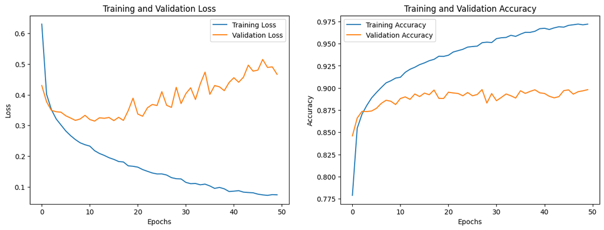

```python
loss_acc(history1.history)
```

- As we can see the model has been `clearly overfitted` i will dercease the complexity of the model by `decreasing the number of nurons` in each layer
- Also after 15 epochs the increase in validation accuracy (89%) has been stopped
- And loss (0.3155) have 15 epochs started increasing therefore will can the `epochs to 15`

#### 2. model layout:

```python
model2 = Sequential([
        Dense(x_train.shape[1], activation='relu',input_shape=(x_train.shape[1],)),
        Dense(64, activation='relu'),
        Dense(64, activation='relu'),
        Dense(32, activation='relu'),
        Dense(32, activation='relu'),
        Dense(10, activation='softmax')
    ])
model2.compile(optimizer='adam', loss='sparse_categorical_crossentropy', metrics=['accuracy'])


model2.summary()

history2 = model2.fit(x_train,y_train, epochs=15 , batch_size=256,validation_data=(x_val, y_val))
```

[output not shown]

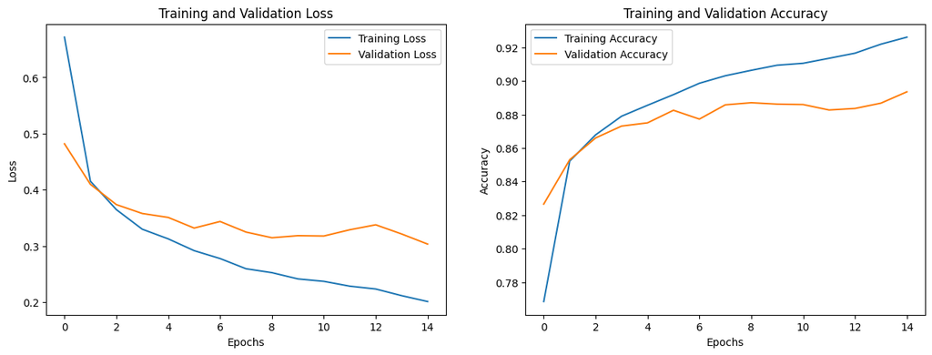

```python
loss_acc(history2.history)
```

- I was able to achieve the `same level of accuracy` with the model with same layers but with less neurons and epochs of 15 with very less overfitting and in very less time the data which can be seen as a huge improvement
- however, i will try to increase the accuracy of the model or decrease the complexity of the model
- This time will `decrease the number of layers` (for less complexity) and keeping the `batch size lower` . lastly also will keep the `epochs to 10` (avoid overfitting)

#### 3. model layout:

```python
model3 = Sequential([
        Dense(x_train.shape[1], activation='relu',input_shape=(x_train.shape[1],)),
        Dense(64, activation='relu'),
        Dense(32, activation='relu'),
        Dense(10, activation='softmax')
    ])
model3.compile(optimizer='adam', loss='sparse_categorical_crossentropy', metrics=['accuracy'])

model3.summary()

history3 = model3.fit(x_train,y_train, epochs=10 , batch_size=64,validation_data=(x_val, y_val))
```

[output not shown]

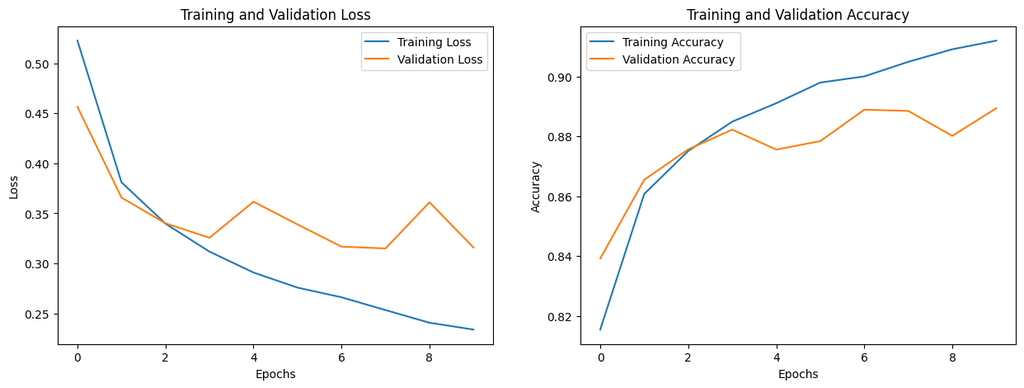

```python
loss_acc(history3.history)
```

This Time i got a very good model with very less complexity, However got some overfitting therefore will make a last model in order to fix is by Further `decrease the layers and nurons`

#### 4. model layout:

```python
model4 = Sequential([
        Dense(x_train.shape[1], activation='relu',input_shape=(x_train.shape[1],)),
        Dense(64, activation='relu'),
        Dense(10, activation='softmax')
    ])
model4.compile(optimizer='adam', loss='sparse_categorical_crossentropy', metrics=['accuracy'])

model4.summary()

history4 = model4.fit(x_train,y_train, epochs=7 , batch_size=64,validation_data=(x_val, y_val))
```

[output not shown]

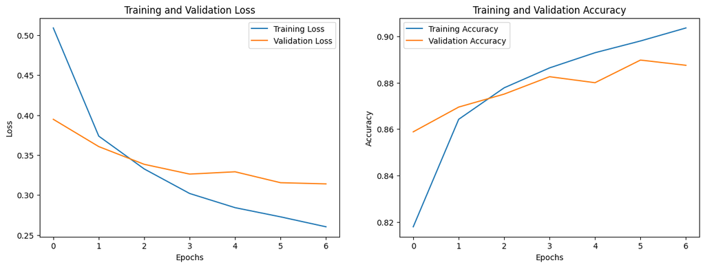

```python
loss_acc(history4.history)
```

## 3. Choose the best configuration, and: Report its accuracy, confusion metric, and specific examples of incorrect classification, and drew some conclusions from this exploration

**All the models almost gave same level of accuracy (88-89%) however i will select the `model4` as it is the `least complex` ANN model amongst all the models**

```python
y_pred = make_pred(model4, test_images)
eval = pd.DataFrame(eval_model(y_pred, test_labels)).T
```

```python
eval.sort_values('f1-score')
```

|  | precision | recall | f1-score | support |
| --- | --- | --- | --- | --- |
| 6 | 0.764259 | 0.6030 | 0.674120 | 1000.0000 |
| 2 | 0.809082 | 0.7840 | 0.796343 | 1000.0000 |
| 4 | 0.770083 | 0.8340 | 0.800768 | 1000.0000 |
| 0 | 0.786972 | 0.8940 | 0.837079 | 1000.0000 |
| macro avg | 0.883581 | 0.8835 | 0.881972 | 10000.0000 |
| weighted avg | 0.883581 | 0.8835 | 0.881972 | 10000.0000 |
| accuracy | 0.883500 | 0.8835 | 0.883500 | 0.8835 |
| 3 | 0.861349 | 0.9070 | 0.883585 | 1000.0000 |
| 7 | 0.932236 | 0.9630 | 0.947368 | 1000.0000 |
| 9 | 0.974066 | 0.9390 | 0.956212 | 1000.0000 |
| 5 | 0.966102 | 0.9690 | 0.967549 | 1000.0000 |
| 8 | 0.979839 | 0.9720 | 0.975904 | 1000.0000 |
| 1 | 0.991820 | 0.9700 | 0.980789 | 1000.0000 |

**Most of the errors are in labels `6,2,4,0`**

```python
for idx in [6,2,4,0,3]:
    print(f'no: {idx} \t label: {label_description_dict[idx]}')
```

```
no: 6 	 label: Shirt
no: 2 	 label: Pullover
no: 4 	 label: Coat
no: 0 	 label: T-shirt/top
no: 3 	 label: Dress
```

These are the predings where the model get most confused

Got the

- Accuracy: 88%
- Precision: 88%
- Recall: 88%
- f1 score: 88%

#### Confusion matrix

```python
import seaborn as sns
```

```python
confusion_matrix(y_pred, test_labels)
```

```
array([[894,   3,  18,  24,   0,   0, 190,   0,   7,   0],
       [  1, 970,   0,   6,   1,   0,   0,   0,   0,   0],
       [ 12,   0, 784,  12,  72,   0,  85,   0,   4,   0],
       [ 34,  22,  14, 907,  33,   0,  35,   0,   7,   1],
       [  2,   3, 130,  30, 834,   0,  79,   0,   5,   0],
       [  0,   0,   0,   0,   0, 969,   0,  21,   1,  12],
       [ 53,   1,  54,  17,  59,   0, 603,   0,   1,   1],
       [  0,   0,   0,   0,   0,  20,   0, 963,   3,  47],
       [  4,   1,   0,   4,   1,   0,   8,   2, 972,   0],
       [  0,   0,   0,   0,   0,  11,   0,  14,   0, 939]], dtype=int64)
```

[figure not shown]

```python
idx_labels = [f"{v}:{k}" for k,v in label_description_dict.items()]
sns.heatmap(pd.DataFrame(confusion_matrix(y_pred, test_labels),columns=idx_labels, index=idx_labels), annot=True , cmap='Greens',fmt=".0f" )
plt.xlabel('Predicted')
plt.ylabel('True')
plt.show()
```

### Specific examples of incorrect classification

```python
incorrect_indices = np.where(test_labels != y_pred)[0]
incorrect_indices
```

```
array([  12,   23,   25, ..., 9977, 9979, 9985], dtype=int64)
```

```python
s=100
np.random.seed(42)
random_idx = np.random.choice(incorrect_indices, size=100, replace=False)
```

```python
plt.figure(figsize=(100, 100))
for i, idx in enumerate(random_idx):
    plt.subplot(10, 10, i + 1)
    plt.imshow(x_val[idx].reshape(28, 28) , cmap ="binary")
    plt.title(f"True: { label_description_dict[y_val[idx]]} \n Pred: {label_description_dict[y_pred[idx]]}", fontsize=64)
    plt.axis('off')

plt.subplots_adjust(wspace=0.4, hspace=0.6)
plt.show()
```

[figure not shown]

The Wrong input given by the model is `genuine` and `very difficult` to classify because there are very similarity in some classes

- For example `T-shirt/Top` and `Shirt` these are almost same classes and is also difficult to classify for me also

Therefore I can say that the model is doing a `great job` of classifying the images